Explore and Summarize Loan Data from Prosper by Rajvir Reehal

Dataset Summary

```
## [1] 113937     81
```

There are 113,937 loans with 81 variables.

```
## [1] "2005-11-09 20:44:28.847000000" "2014-03-10 12:20:53.760000000"
```

The dataset I will be exploring is loan data from Prosper, a peer-to-peer lending platform. Borrowers can borrow up to $2,000 to $35,000 from the marketplace and lenders can base their decision on the borrowers credit history and loan information.

I will being my analysis with a short summary of the data and then I will create univariate plots to understand the structure of individual variables I am interested in learning more about.

# Univariate Plots Section

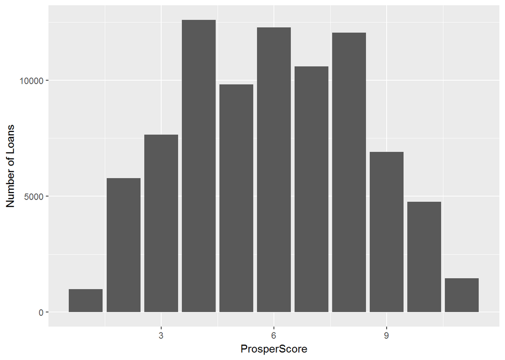

The Prosper Score risk rankings looks normally distriuted with the mean close to 6.

I noticed 29,084 rows of data consisted of NA. After looking further into it, I noticed it these loans originated before before July 2009. Loans that originated before July 2009 do not have data for ProsperScore, ProsperRating (alpha), ProsperRating (numeric), EstimatedReturn, EstimatedEffectiveYield, and EstimatedLoss.

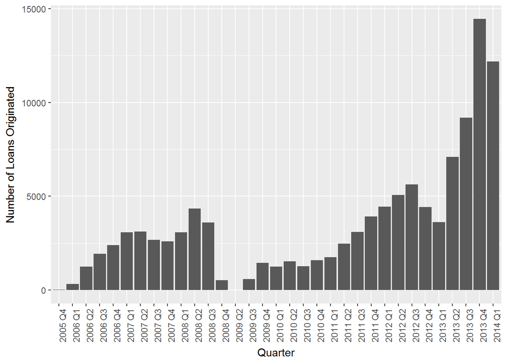

Since the company was founded in 2005 to Q2 of 2008, the company saw a steady increase in the number of loans originated. But as most of the developed world dove deep into the recession, the number of loan originations decreased significantly untl there were no loans originating in Q1 2009.

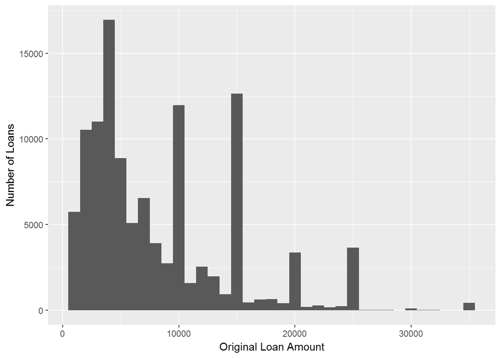

```
##    Min. 1st Qu.  Median    Mean 3rd Qu.    Max.
##    1000    4000    6500    8337   12000   35000
```

Most of the loans had a principal amount of less than $10,000 with a mean of $8,337 and median of $6,500. We can see peaks in the plot at multiples of $5,000 up to 30,000.

Let’s examine that reasons for taking out these loans.

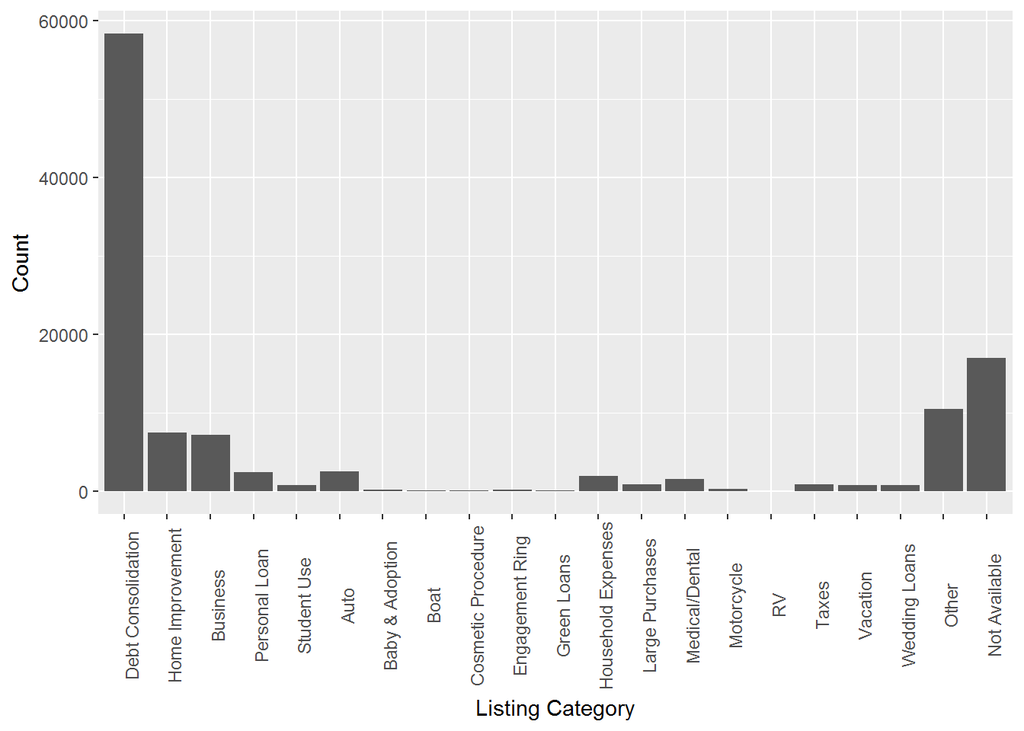

Quite a large portion of loans are taken out for the purpose of consolidating loans. This could indicate that a large amount of borrowers do not have a high enough income to pay off their loans quickly, or they aren’t responsible with their finances and take on more debt than they should, or they are at a point in their life where they are taking on debt (fist car, first home, paying off student loans) and they’re just looking to lower their interest payments by consolidating. Let’s examine this further.

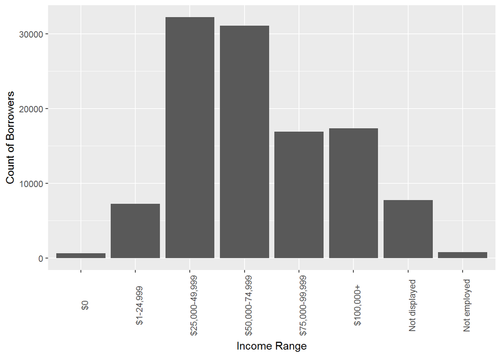

Most of the borrowers have incomes inbetween $25,000-$49,999 and $50,000-$74,999.

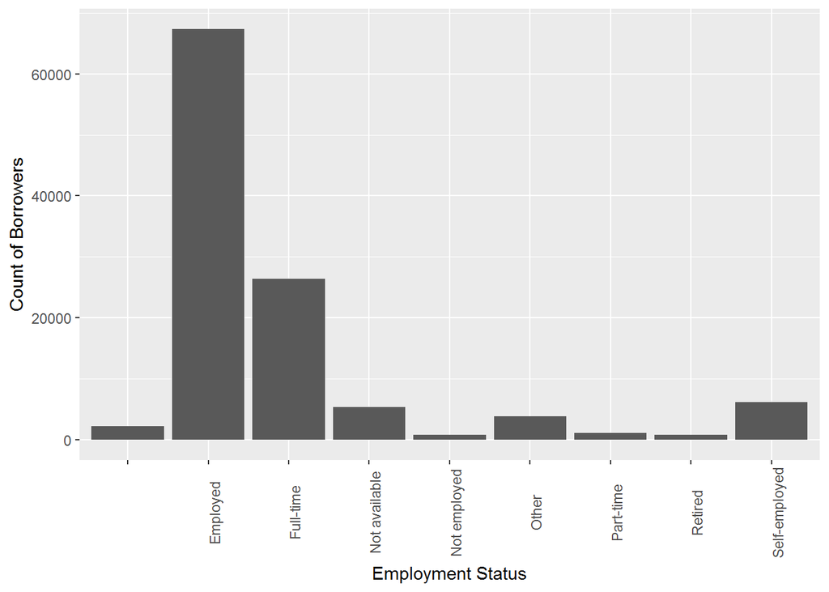

Most of the borrwers have identified themselves as employed, however they did not povide any more details about the type of employment.

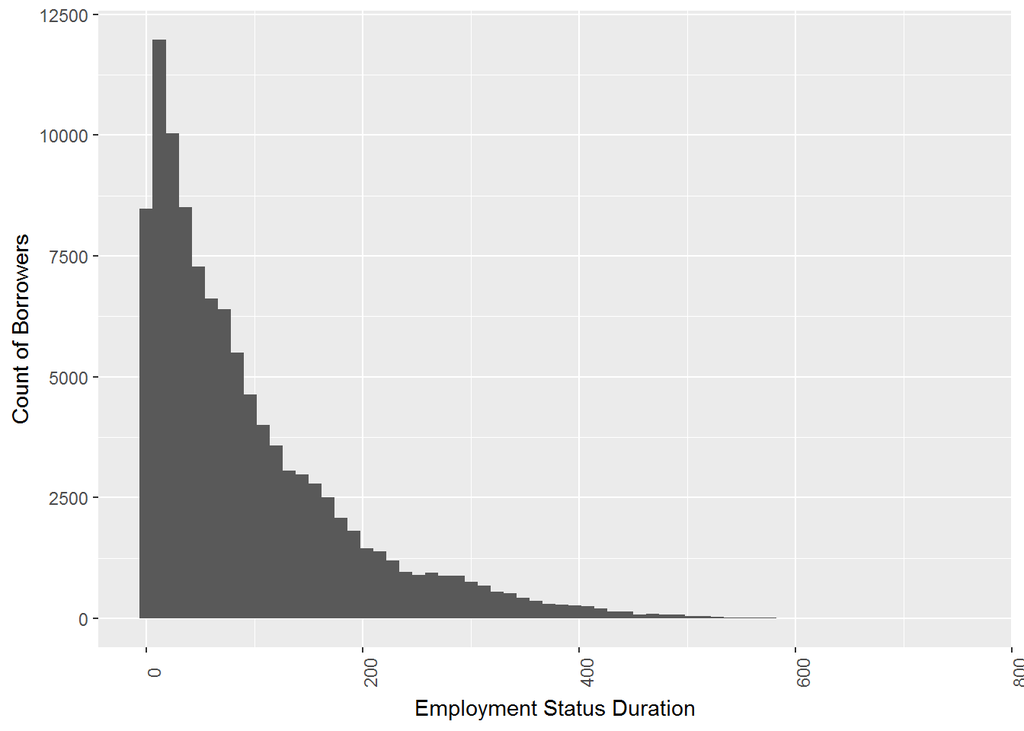

```
##    Min. 1st Qu.  Median    Mean 3rd Qu.    Max.    NA's
##    0.00   26.00   67.00   96.07  137.00  755.00    7625
```

This graph exhibits a right-skewed disribution as the plot immediately preaks then tails out as the employment status durration increases. 7625 rows of data were removed when making this plot as that many loans did not have data for EmploymentStatusDuration.

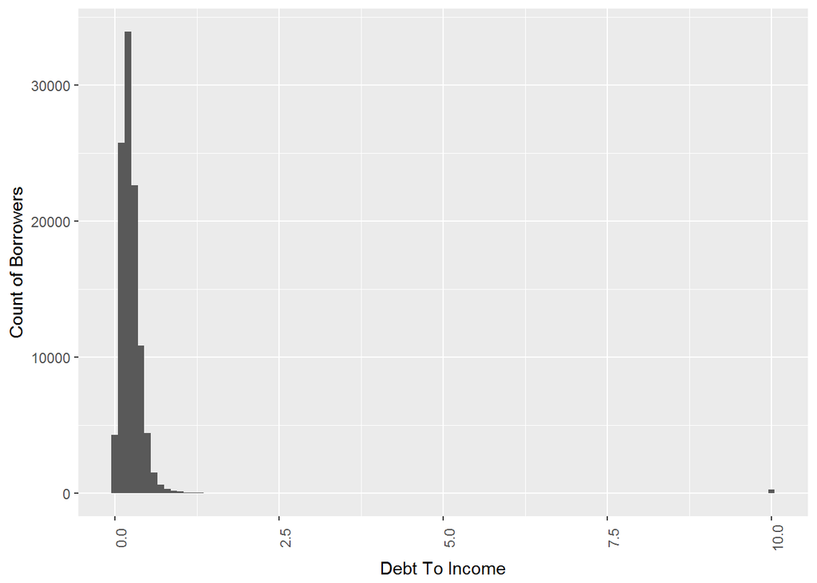

We have a large outlier which is making it difficult to view the plot. Let’s remove the outlier for a better visualization.

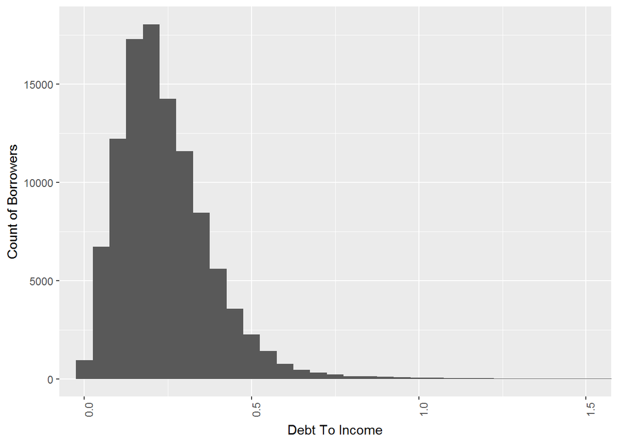

```
##    Min. 1st Qu.  Median    Mean 3rd Qu.    Max.    NA's
##   0.000   0.140   0.220   0.276   0.320  10.010    8554
```

The majority of borrowers have a debt-to-income ratio of less than 0.5. We can see after zooming in, this plot is slightly right-skewed and there is a tail on the right. The median ratio is 0.22 and 75% of borrowers have a ratio of less than 0.32.

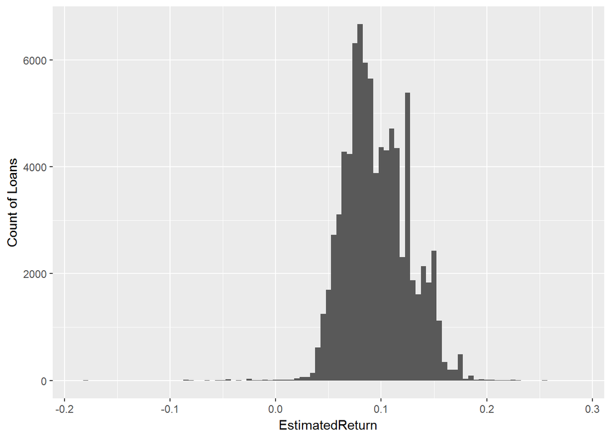

```
## $x
## [1] "Estimated Return"
##
## attr(,"class")
## [1] "labels"
```

```
##    Min. 1st Qu.  Median    Mean 3rd Qu.    Max.    NA's
##  -0.183   0.074   0.092   0.096   0.117   0.284   29084
```

The plot seems to follow a normal distribution with a mean of 9.6%. Which is a great return margin. Let’s plot how much borrowers are paying for their loans.

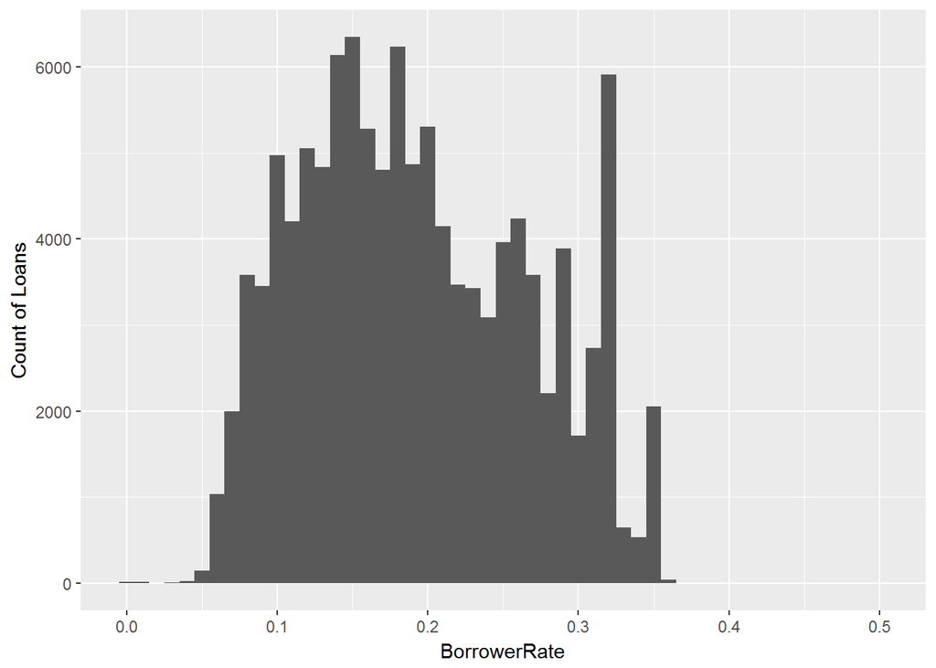

```
## $x
## [1] "Borrower Rate"
##
## attr(,"class")
## [1] "labels"
```

```
##    Min. 1st Qu.  Median    Mean 3rd Qu.    Max.
##  0.0000  0.1340  0.1840  0.1928  0.2500  0.4975
```

The plot seems to follow a normal distributon with a right skew. The mean borrowing rate is 19.28%. That’s a very high rate to pay every year.

Let’s examine how long borrowers are borrowing for. It would be very interesting to see how much of their income goes towards interest payments.

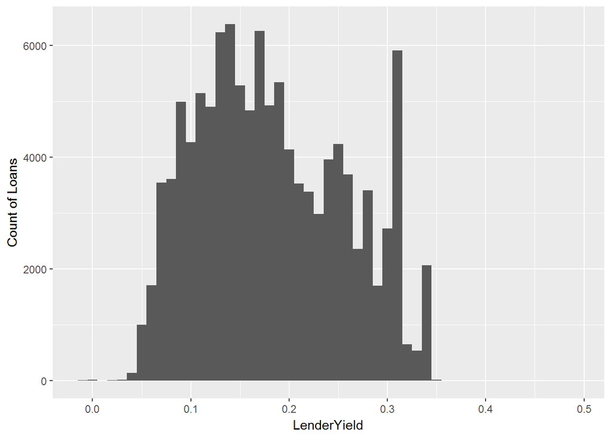

```
## $x
## [1] "Lender Yield"
##
## attr(,"class")
## [1] "labels"
```

```
##    Min. 1st Qu.  Median    Mean 3rd Qu.    Max.
## -0.0100  0.1242  0.1730  0.1827  0.2400  0.4925
```

Most of the lender yields are between 5% and 35%. The plot follows a normal distribution with a right-skew and a peak near 31%.

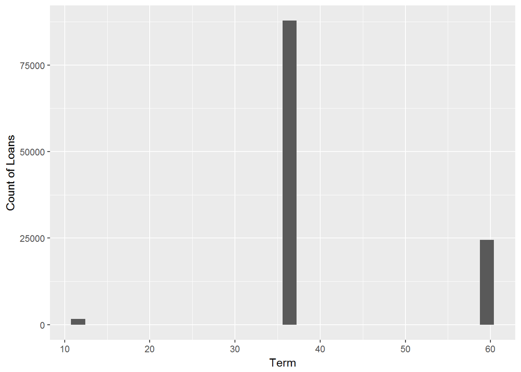

```
##    Min. 1st Qu.  Median    Mean 3rd Qu.    Max.
##   12.00   36.00   36.00   40.83   36.00   60.00
```

All of the loans seems to be offered in a 1-year, 3-year, or 5-year term. Most of the loans are 3-year loans. This is quite a long time to pay a mean interest borrowing rate of 19.28%. Over three years, a borrower would be paying almost 60% of the original loan value in interest payments.

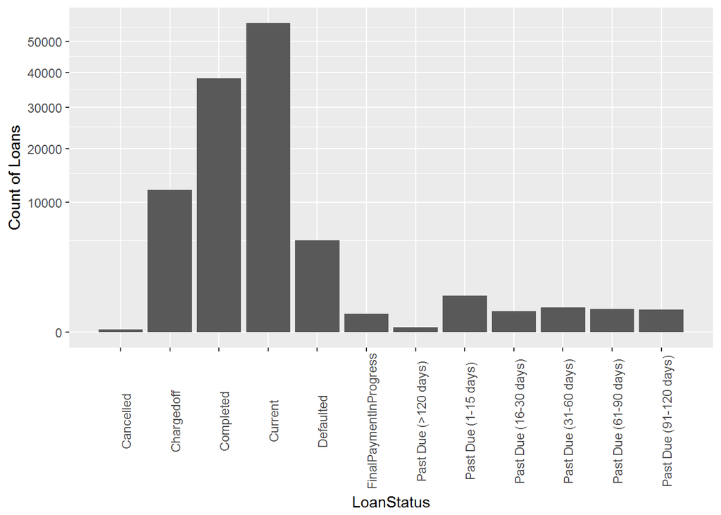

Most of the loans are either completed or are current loans. However, there is a large amount of charged-off and defaulted loans. Further into the analysis I want to see if the propsre rating is accurate in determining if a loan will perform or not.

# Univariate Analysis

### What is the structure of your dataset?

The structure of the dataset consists of 81 variables with 113937 observations. Each observation is a loan and the variables describe the loans with details of the loan and details of the borrower. The observations are from 2005 to 2014. The variable types are int, num, and ch.

### What is/are the main feature(s) of interest in your dataset?

The main features of interest in the dataset are the yield and return rates along with the various amount of loan characteristics. This will allow me to guess what are the common loan characteristics of loans that become delinquent and what loans characteristics makes the loan a safe investment.

Another feature which interested me what how I can view through plots the effects of the recession on the loan market

### What other features in the dataset do you think will help support your investigation into your feature(s) of interest?

The other fetures in the dataset that will help support my investigation are the current credit line, total inquires, revolving monthly payments, and bank card utilization variables.

### Did you create any new variables from existing variables in the dataset?

I did not see a need to create new variables at this point of the analysis.

### Of the features you investigated, were there any unusual distributions? Did you perform any operations on the data to tidy, adjust, or change the form of the data? If so, why did you do this?

In the Lender Yield and Borrower Rate plots, there is an unusual spike at the 31% and 32% points in the plot, respectively, which I may try to explain as I investigate further.

As for the second question, I factorized categorical variables to order them in a manner to make the plot readable.

# Bivariate Plots Section

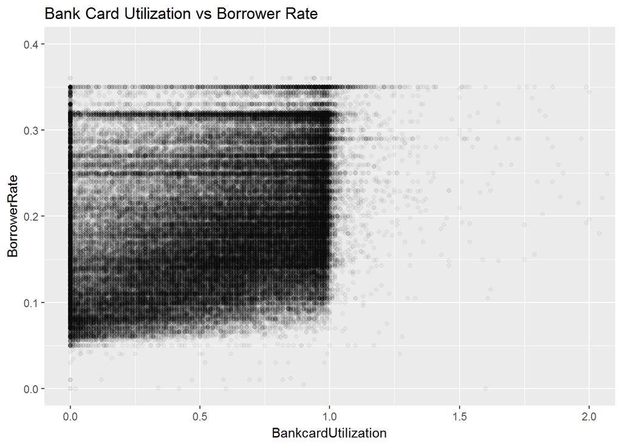

For this plot, I was expecting the borrower rate to increase as bank card utilization increased because a high bank card utilization rate may indicate that the borrower is not able to pay off their credit card frequently and thus has to pay the high interest rates on credit cards.

Maybe there are relationships between the utilization rate and other variables that are in play here as the utilization rate increases.

Another interesting feature of this plot is that at the 100% utilization rate there seems to be a limit, however there are a small amount of loans above the 100% utilization rate. This could be because of the new credit requirements that banks and landers had to follow which the government introduced after the recession or maybe it could be that once borowers hit 100% of their card utilization, they looked elsewhere for credit.

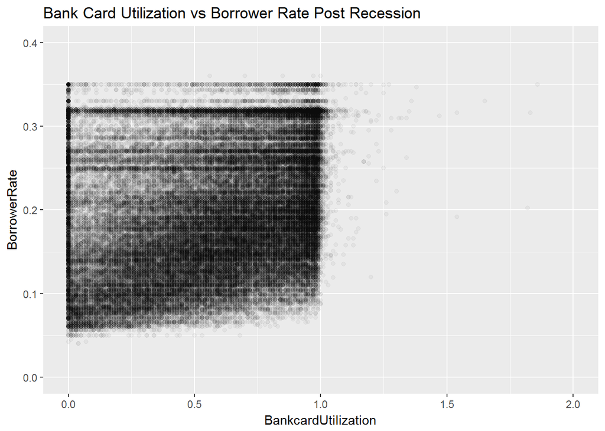

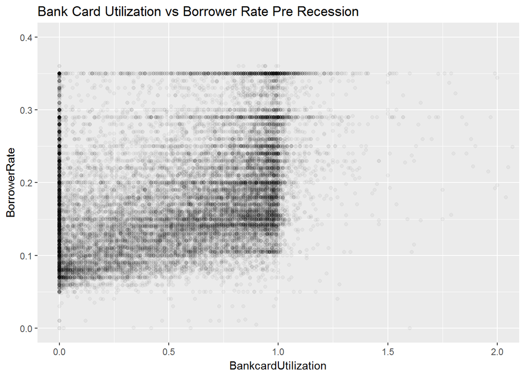

We can see that the limit at 100% utilization in the post recession plot a more defined than the pre recession plot. There are many more loans that have > 100% card utilizaion pre recession than post recession, this could be due to more stringent borrowing requirements enacted by Prosper after the recession.

Let’s conduct a correlation test to measure the strength of this relationship.

```r
cor.test(pld$BankcardUtilization, pld$BorrowerRate, method = "pearson")
```

```
##
##  Pearson's product-moment correlation
##
## data:  pld$BankcardUtilization and pld$BorrowerRate
## t = 86.168, df = 106330, p-value < 2.2e-16
## alternative hypothesis: true correlation is not equal to 0
## 95 percent confidence interval:
##  0.2498551 0.2610917
## sample estimates:
##      cor
## 0.255482
```

With a p-value of 2.2e-16, this is much less than the significance level of alpha = 0.05. We can conclude that bank card utilization and borrower rate are significantly correlated.

Let’s continue investigating what effects the borrower rate.

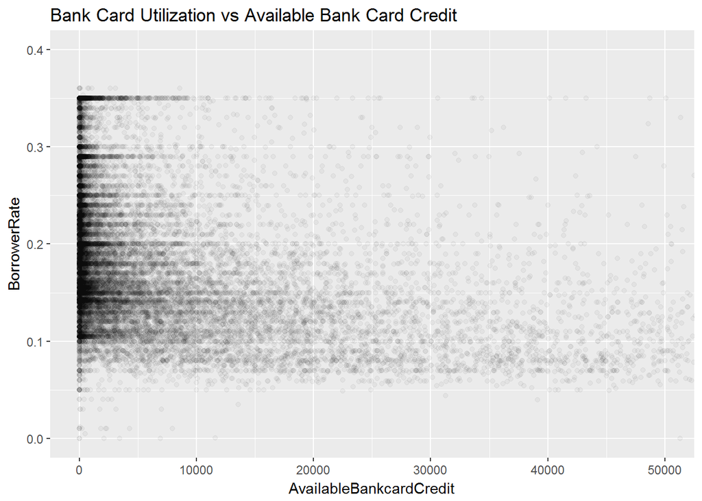

We can see that most of the loans with borrowers that have a high amount of available credit have a lower borrower rate as expected.

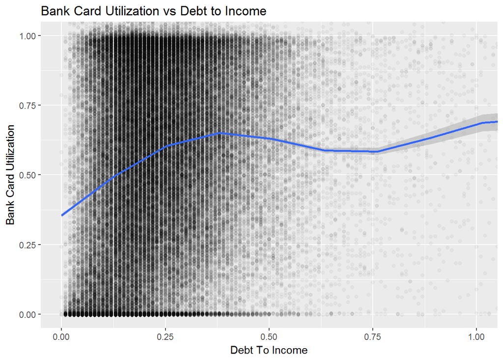

The two variables have a positive relationship at a debt to income of approximately 0.4, then seems to fall and rise where there are not a great number of loans.

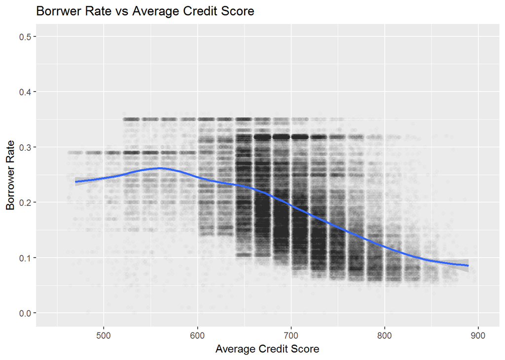

There seems to be a negative relationship between the two variables. For the credit scores over 750, the borrower rate is low and the ranges of borrowing rates is smaller for most of the loans compared to borrowing rates for borrowers with lower credits scores.

Let’s compare the borrower rate with the prosper score to see if there is a stronger relationship.

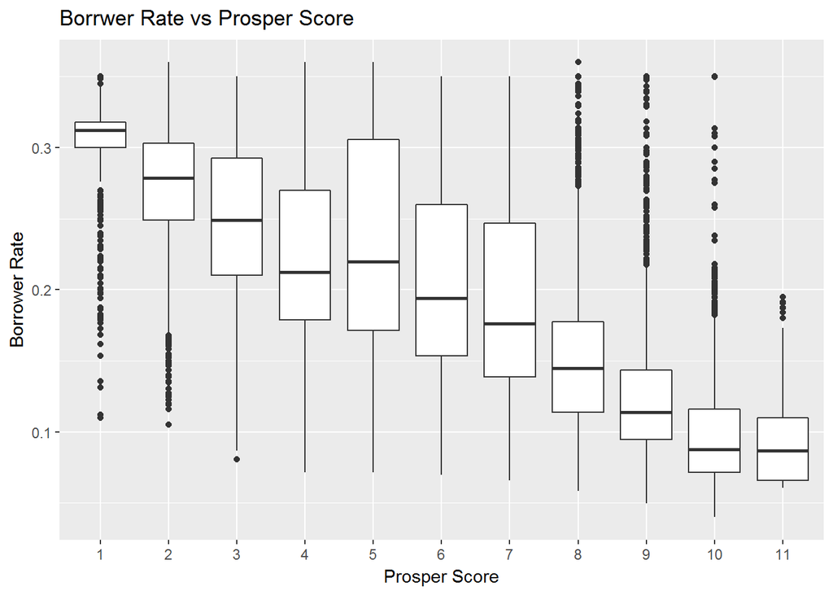

As we can see, the higher the prosper score for a loan, the lower the borrowing rate is.

But how accurate are prosper scores in determining if a loan will perform or not?

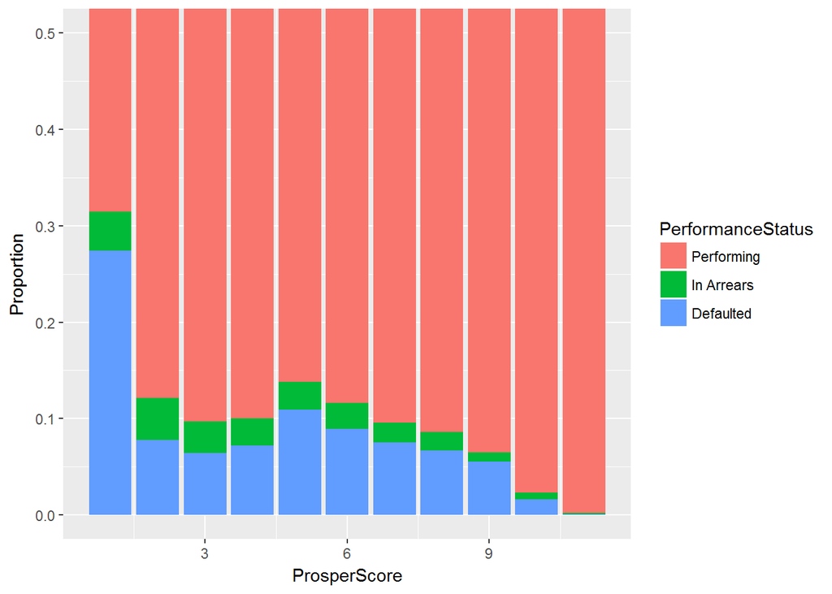

Prosper scores 5-11 follow the pattern I was expecting. I am surprised by the difference in the default rates from prosper score 1 to score 2. And it’s surprising that prosper scores 2-4 have a similar performance of loans with scores of 6-8.

Another interesting observation is the large amount of defaults for loans originated before before July 2009.

Let’s take a look into the return rates for borrowers for each quarter. Based on this plot, I expect return rates to be much lower before July 2009 than return rates after July 2009.

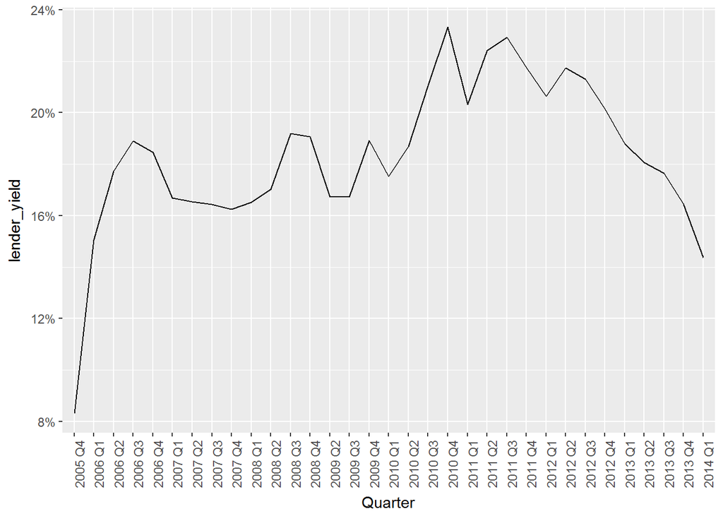

We have to keep in mind that the plot graphs the estimated lender yield as it is calculated at the origination of the loan. Lender yield rose until Q4 2010 and started falling.

Next I will calculate the actual return on a loan by subracting losses(if any) from the original loan amount and will annulize the return.

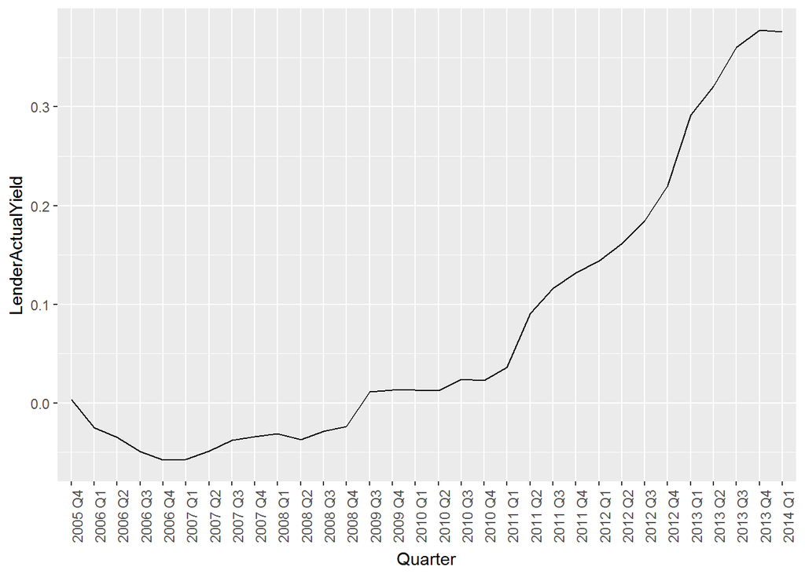

By the calculations, Prosper lenders experienced losses from Prosper’s inception and through the recession and provided positive returns after prosper was required to register with the SEC. Q2 2009 was quite interesting as all loans received $0 in customer payments, therefore it was removed from the plot to make it more readable.

For loans that have existed for less than 12 months and are in good standing their returns were annualized.

# Bivariate Analysis

### Talk about some of the relationships you observed in this part of the investigation. How did the feature(s) of interest vary with other features in the dataset?

I was expecting to see stronger relationships in the plots between borrower rate and other variables such as debt to income and bank card utilization.

### What was the strongest relationship you found?

The relstionship between the Prosper score and borrower rate.

# Multivariate Plots Section

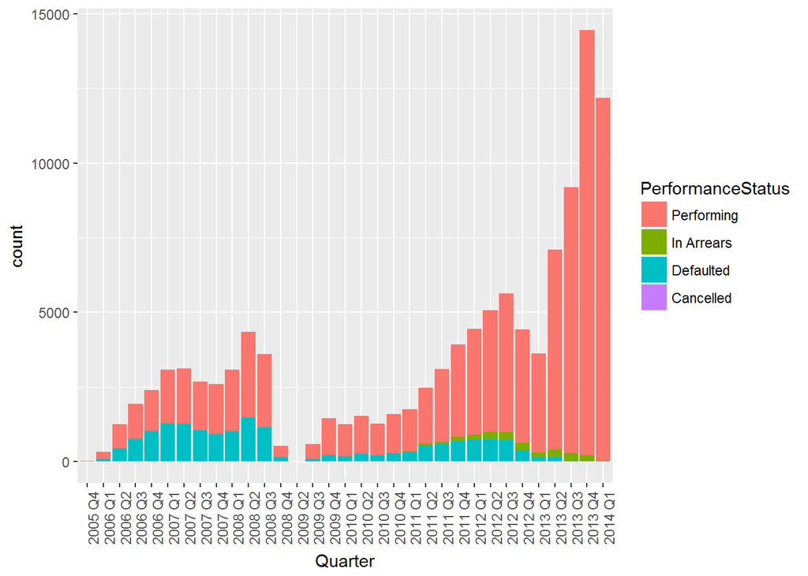

There are a greater proportion and number of defaulted loans before the recession that after the recession. This can be attributed to Prosper’s registration with the SEC.

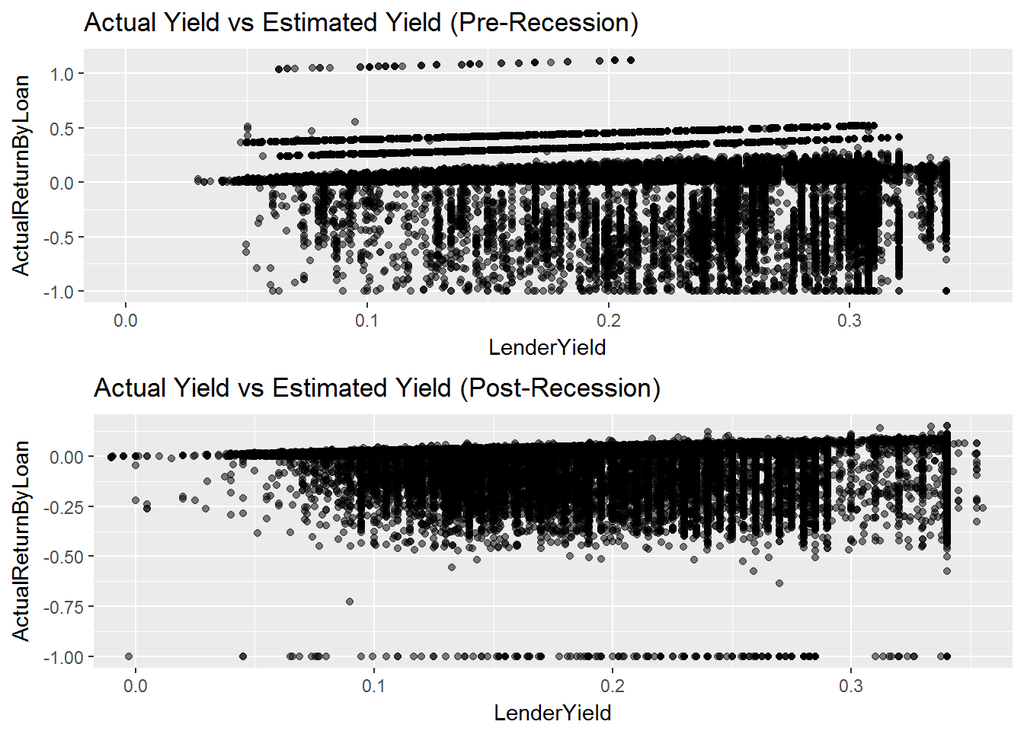

I created these plots to determine how accurate the lender yield was compared to the actual return of each loan. I split the graphs with pre-recession and post-recession loans to see the difference in actual returns after Prosper registered with the SEC.

We can see for most loans that the actual return was lower than the predicted lender yield. We can also see the change in distribution between the two plots before and after the recession; loans that experienced losses realized greater losses before the recession than after.

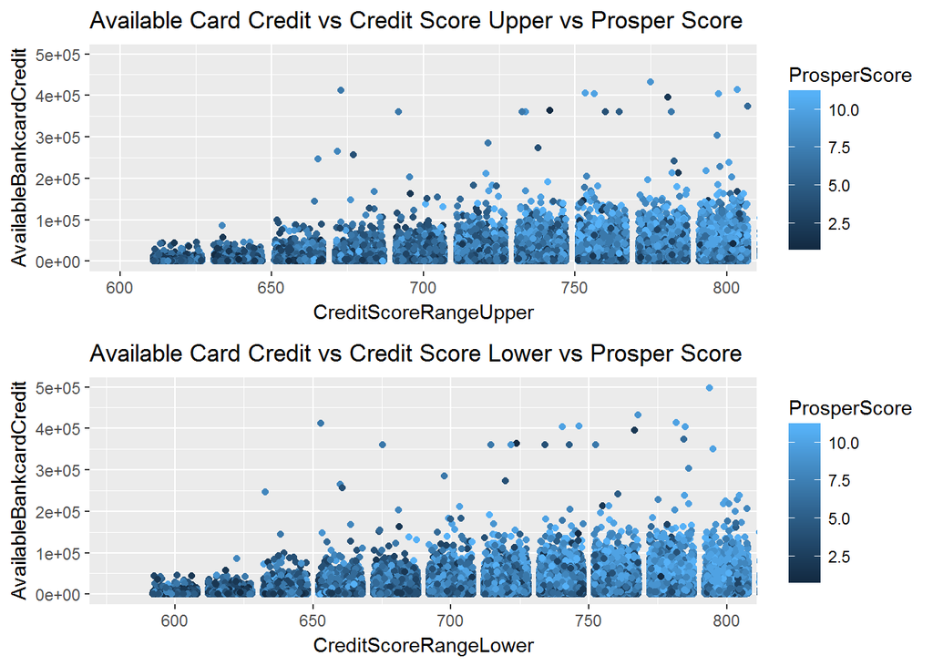

This plots the relationship between the available card credit and credit score and their effect in calculating ther Prosper Score. As credit score rises, so does the available bank card credit. And in each column grouping that was created, the share of higher prospe score loans increases as the cresit score increases.

# Multivariate Analysis

### Talk about some of the relationships you observed in this part of the investigation. Were there features that strengthened each other in terms of looking at your feature(s) of interest?

As I saw the realtionship that available bank card credit and credit scores had with the borrower rate in the bivariate plots section, it indicated these variables were used the the model to create the Prosper Score as this relationship can be viewed in the plots above.

### Were there any interesting or surprising interactions between features?

The large share of defaulted loans in the quarters before the recession were very surprising to me as it should’ve been a red flag to lenders trying to invest their savings in Prosper loans.

The actual return by loan before and after the recession were interesting as well. Prosper tightened their borrower requirements to reduce that number of defaulted loans and it can be visualized through the first two plots.

### OPTIONAL: Did you create any models with your dataset? Discuss the strengths and limitations of your model.

# Final Plots and Summary

### Plot One

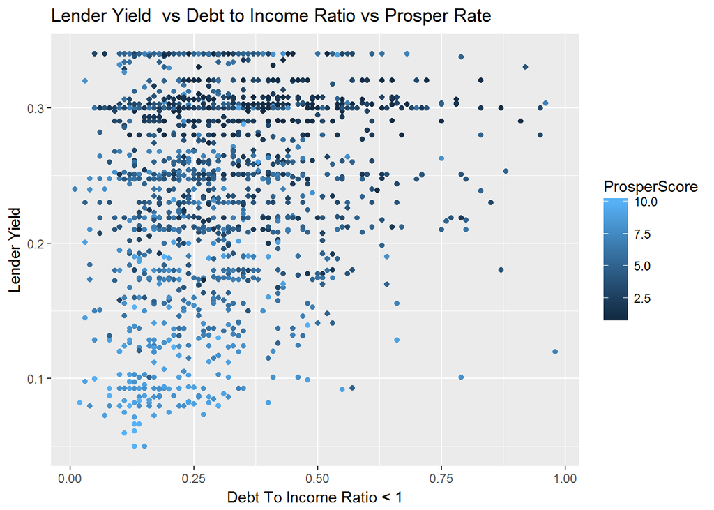

### Plot Two

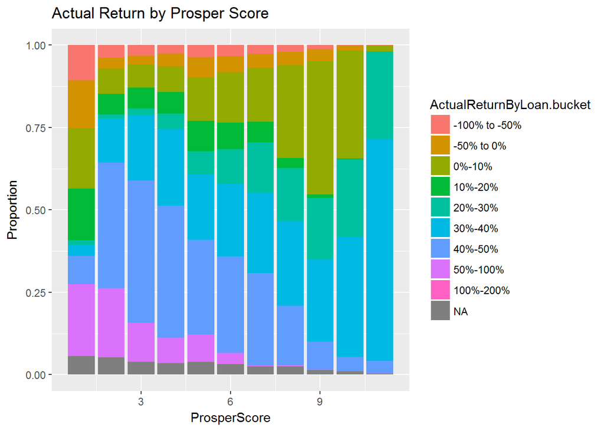

### Plot Three

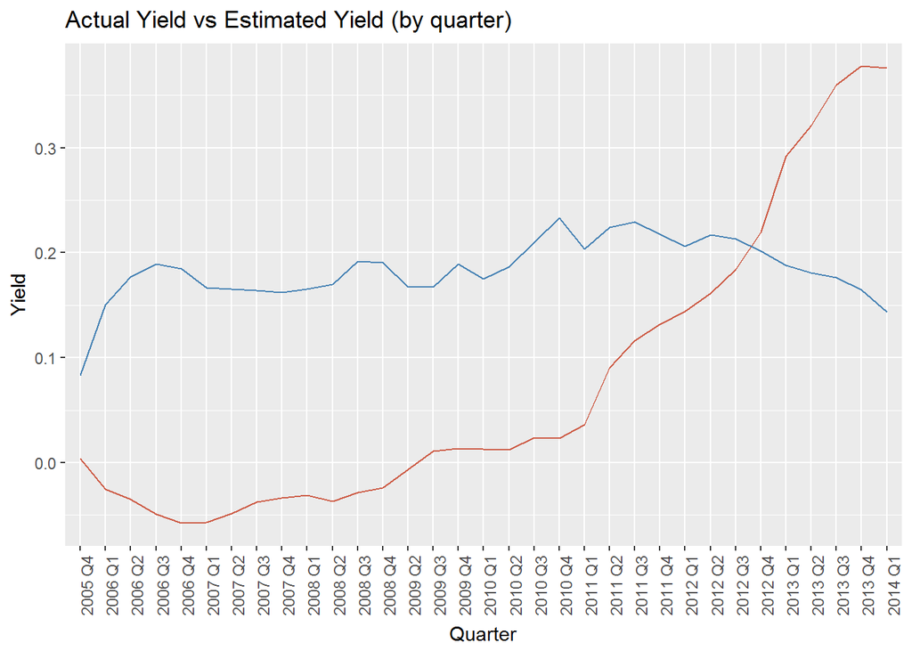

### Description Three

For the third graph, I decided to keep it simple and plotted the actual yield vs the estimated yield. This is to show the great difference between them two. I’m sure all of the lenders that experienced losses with Prosper would be very frsustrated at seeing these results as it’s apparent that Prosper didn’t do their due diligence in screening their borrowers until they were forced to register with the SEC.

# Reflection

This dataset was very interesting to analyze. There were some variables that I expected to have a strong relationship to the estimated yield, but didin’t. This made me realize that there are many other variables to consider when determining the risk of an individual borrower. However, I did expect to see a stronger relationship between the credit card utilization and the borrower rate as credit card utilization, to me, determines if a borrower understand how inefficient it is to borrow money from a credit card as they have very high interest rates. If a borrower has high credit card utilization then I’d deem them to be a risky borrower as they don’t seem to understand what should be their financial priorities.

This project made me a lot more comfortable with using R as it forced me to manipulate the data, create different types of plots, create new variables to see new insights, and to choose the best way to visualize the data. I struggles with some of the data manipulation, but searching the web made it a lot easier to solve as many other people have documented similar struggles along with their solutions.

If I had more time with the dataset, I would have tried to create a model that mimics the way the Prosper score is calculated.